# Analysis: Exploratory Data Analysis

## Introduction

This markdown imports the processed data and conducts the exploratory data analysis. Follow the processing markdowns in the `processing_code` folder to generate the processed data.

This analysis examines the predictors of allocation of FEMA funds during disaster declarations. In terms of the datasets, the two outcomes of interest are Requested Amount (`ReqAmt`) and Obligated Amount (`OblAmt`).

For each variable, the following steps will be completed:

1. Produce and print some numerical output (e.g. table, summary statistics)
2. Create a histogram or density plot (continuous variables only)
3. Scatterplot, boxplot, or other similar plots against the main outcome of interest
4. Any other exploration steps that may be useful.

The steps will be numbered for each variable as specified above.

## Required Packages

The following R packages are required for this script:

- here: for path setting
- tidyverse: for all packages in the Tidyverse (ggplot2, dyplr, tidyr, readr, purr, tibble, stringr, forcats)
- skimr: for data summarization
- summarytools: for overall dataframe summary
- ggplot2: for plotting data
- car: for creating QQ plots
- gtsummary: for creating tables for summary statistics / other numerical outputs
- scales: for percent calculation and axis formatting
- cowplot: for placing plots side by side
- table1: for making summary tables

## Load Processed Data

Load the data generated from the markdowns in the `processing_code` folder.

```r
#define file path
data_location <- here::here("data", "processed_data", "combinedprocessed.rds")

#load data
EDAdata <- readRDS(data_location)
```

## Data Overview

To better understand the data, let’s use `summarytools` to better visualize the data.

```r
summarytools::dfSummary(EDAdata)
```

```
## Data Frame Summary
## EDAdata
## Dimensions: 446 x 21
## Duplicates: 0
##
## ----------------------------------------------------------------------------------------------------------------------------
## No   Variable           Stats / Values                      Freqs (% of Valid)    Graph                 Valid      Missing
## ---- ------------------ ----------------------------------- --------------------- --------------------- ---------- ---------
## 1    state              1. LA                                22 ( 4.9%)                                 446        0
##      [character]        2. TX                                21 ( 4.7%)                                 (100.0%)   (0.0%)
##                         3. CA                                20 ( 4.5%)
##                         4. FL                                18 ( 4.0%)
##                         5. WV                                16 ( 3.6%)
##                         6. MS                                15 ( 3.4%)
##                         7. NC                                14 ( 3.1%)
##                         8. GA                                13 ( 2.9%)
##                         9. SC                                13 ( 2.9%)
##                         10. OK                               12 ( 2.7%)
##                         [ 41 others ]                       282 (63.2%)           IIIIIIIIIIII
##
## 2    disasterNumber     Mean (sd) : 4100.9 (418.7)          445 distinct values   :           . :   .   446        0
##      [integer]          min < med < max:                                          :           : : : :   (100.0%)   (0.0%)
##                         3345 < 4237.5 < 4624                                      :           : : : :
##                         IQR (CV) : 859.2 (0.1)                                    : :       : : : : :
##                                                                                   : :       : : : : :
##
## 3    IncidentYear       Mean (sd) : 2017 (2.9)              2012 :  43 ( 9.6%)    I                     446        0
##      [numeric]          min < med < max:                    2013 :  41 ( 9.2%)    I                     (100.0%)   (0.0%)
##                         2012 < 2018 < 2021                  2014 :  26 ( 5.8%)    I
##                         IQR (CV) : 5 (0)                    2015 :  37 ( 8.3%)    I
##                                                             2016 :  27 ( 6.1%)    I
##                                                             2017 :  48 (10.8%)    II
##                                                             2018 :  42 ( 9.4%)    I
##                                                             2019 :  41 ( 9.2%)    I
##                                                             2020 : 115 (25.8%)    IIIII
##                                                             2021 :  26 ( 5.8%)    I
##
## 4    IncidentMonth      Mean (sd) : 5.6 (3.6)               12 distinct values    :                     446        0
##      [numeric]          min < med < max:                                          :                     (100.0%)   (0.0%)
##                         1 < 6 < 12                                                :
```

[output cut: 99 more lines]

```
##                         IQR (CV) : 1467763 (7.4)                                  :
##                                                                                   :
##
## 20   OblAmt             Mean (sd) : 29744109 (219676789)    332 distinct values   :                     446        0
##      [numeric]          min < med < max:                                          :                     (100.0%)   (0.0%)
##                         -855200.3 < 109471.6 < 4408424297                         :
##                         IQR (CV) : 1470450 (7.4)                                  :
##                                                                                   :
##
## 21   FEMACSAvg          Mean (sd) : 0.8 (0.4)               137 distinct values                     :   446        0
##      [numeric]          min < med < max:                                                            :   (100.0%)   (0.0%)
##                         0 < 1 < 1                                                                   :
##                         IQR (CV) : 0.1 (0.4)                                                        :
##                                                                                   :             . . :
## ----------------------------------------------------------------------------------------------------------------------------
```

Let’s dive a little deeper into each variable.

## Outcome of Interest: Requested FEMA Funds

The first of two primary outcomes of interest is the total amount of funds the state requested from the federal government for a disaster declaration.

```r
#summary statistics
base::summary(EDAdata$ReqAmt)
```

```
##       Min.    1st Qu.     Median       Mean    3rd Qu.       Max.
##    -855200          0     109472   29673687    1467763 4388540486
```

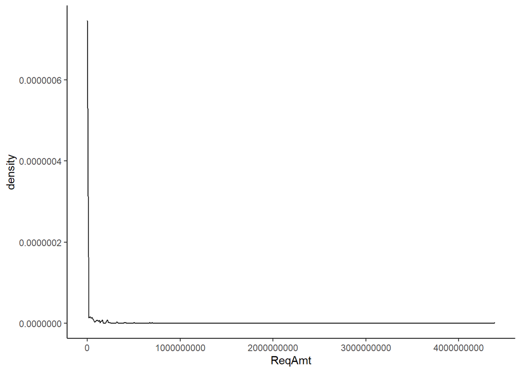

```r
#density plot
ggplot2::ggplot(data = EDAdata, aes(x = ReqAmt)) +
  geom_density()
```

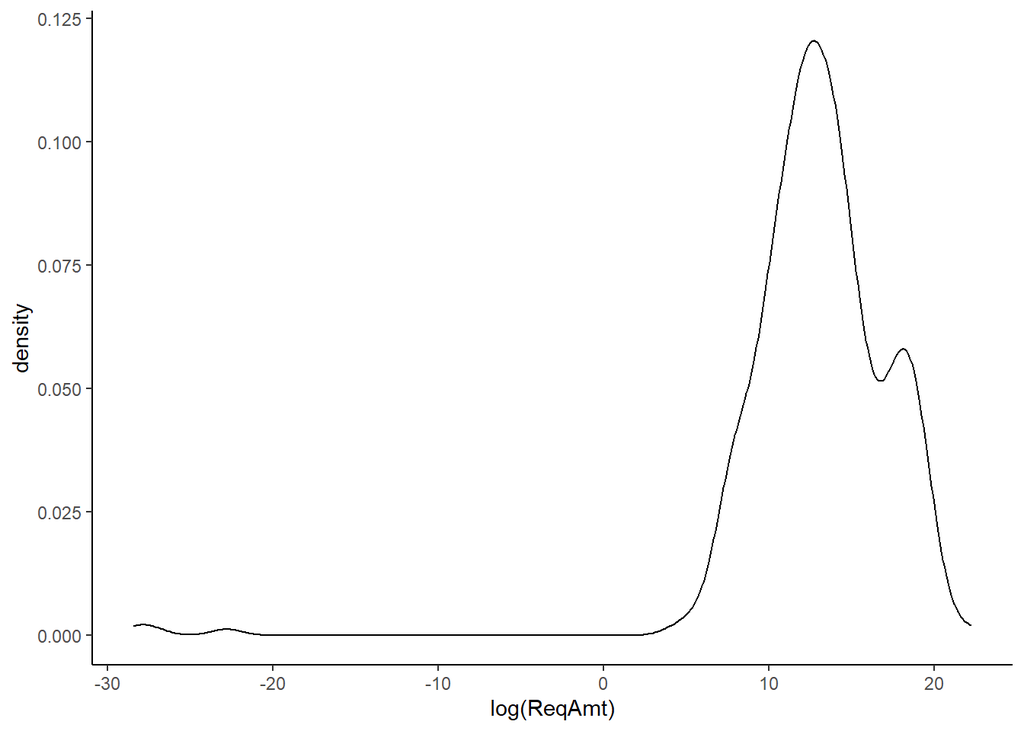

```r
#try a log transformation out of curiosity
#this does ignore all negative values
ggplot2::ggplot(data = EDAdata, aes(x = log(ReqAmt))) +
  geom_density()
```

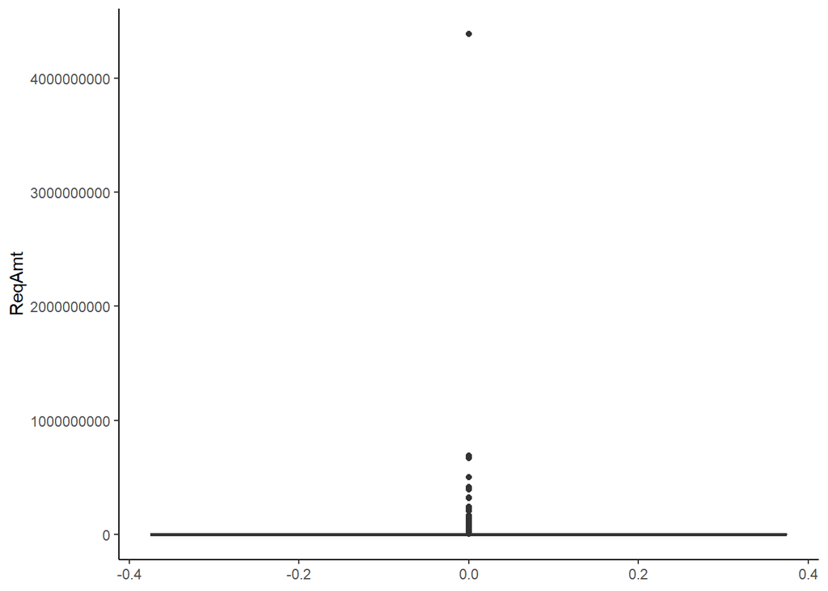

```r
#normal boxplot
ggplot2::ggplot(data = EDAdata, aes(y = ReqAmt)) +
  geom_boxplot()
```

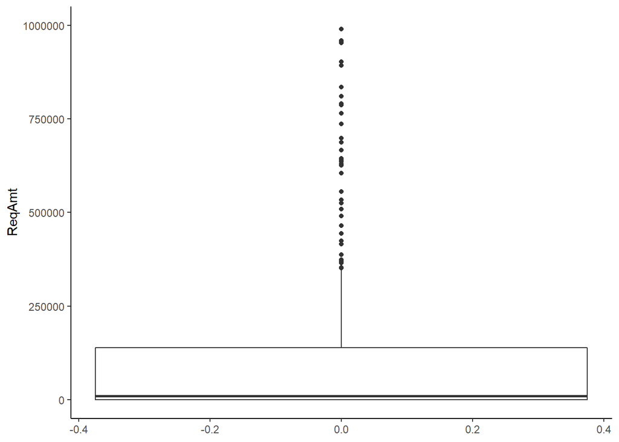

```r
#crop to $1M to get a better idea
ggplot2::ggplot(data = EDAdata, aes(y = ReqAmt)) +
  geom_boxplot() +
  ylim(0, 1000000)
```

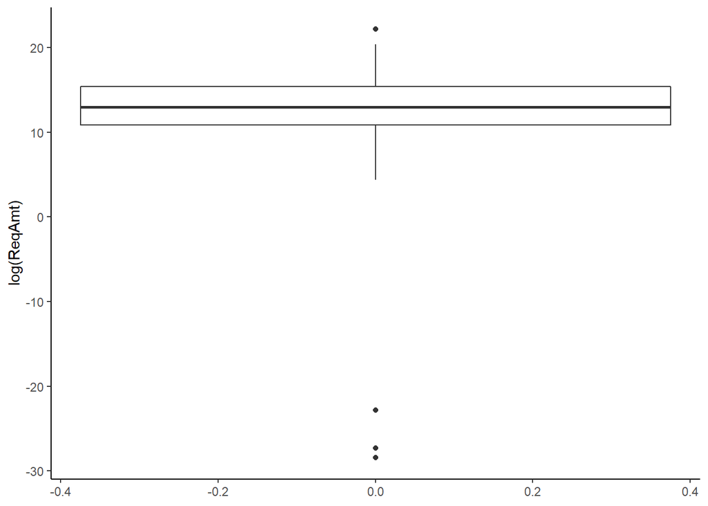

```r
#log transformed boxplot
ggplot2::ggplot(data = EDAdata, aes(y = log(ReqAmt))) +
  geom_boxplot()
```

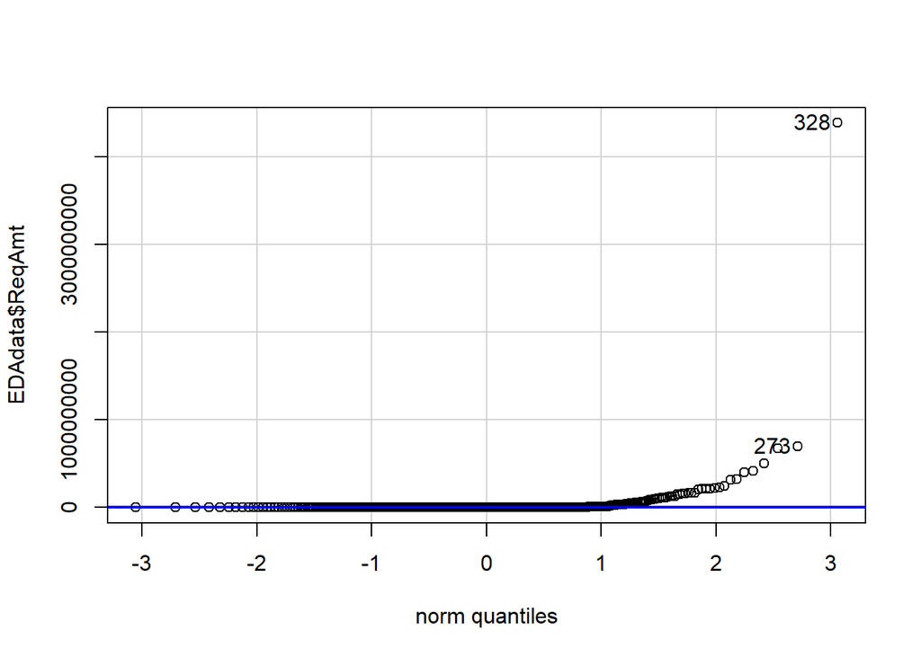

```
## [1] 328 273
```

```r
##QQ plot
car::qqPlot(EDAdata$ReqAmt)
```

These outputs show the requested amounts do not follow a normal distribution, which is to be expected given the broad range of disasters. We may need to remove outliers in the analysis, but for now, we’ll leave them to capture the true nature of disaster declarations. The largest outlier is likely the COVID-19 Pandemic. The log transformation does a better job of showing the distribution of the data, so we may need to consider an exponential model in the analysis; however, log(negative number) is undefined, so we would be ignoring all reimbursement data. The transformed and untransformed figures suggest there are significant tails in the data.

## Outcome of Interest: Obligated FEMA Funds

The alternative outcome of interest is the funding obligated from FEMA. While this may be the same as `ReqAmt` (especially for large-scale disasters), FEMA doesn’t always pay the amount the states request.

```r
#summary statistics
base::summary(EDAdata$OblAmt)
```

```
##       Min.    1st Qu.     Median       Mean    3rd Qu.       Max.
##    -855200          0     109472   29744109    1470450 4408424297
```

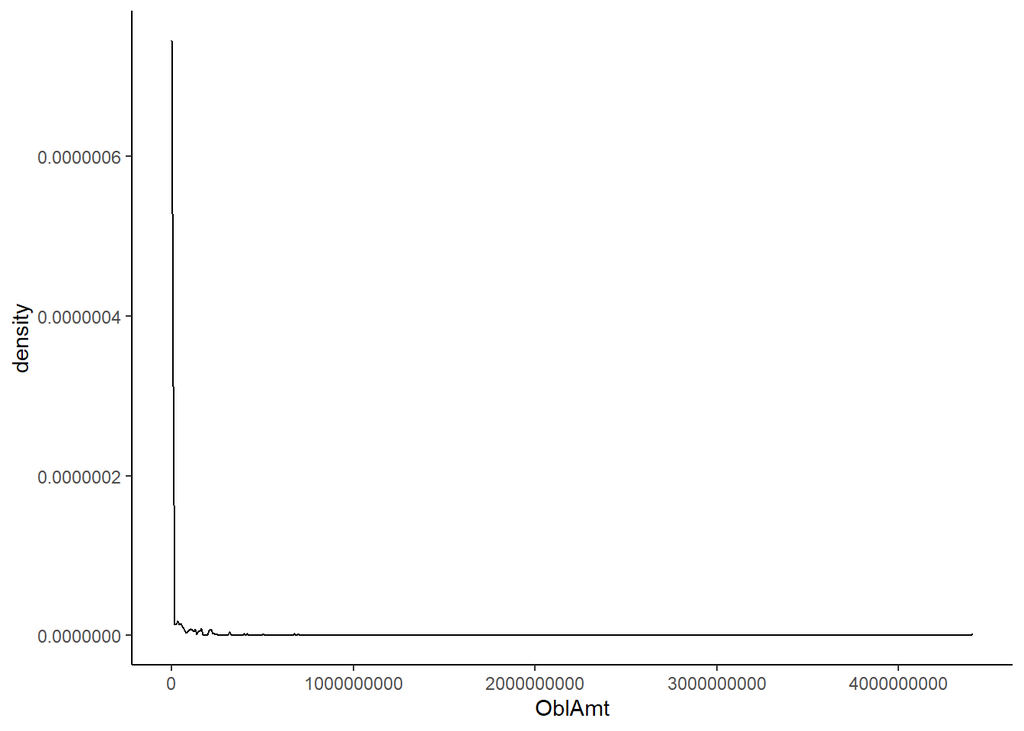

```r
#density plot
ggplot2::ggplot(data = EDAdata, aes(x = OblAmt)) +
  geom_density()
```

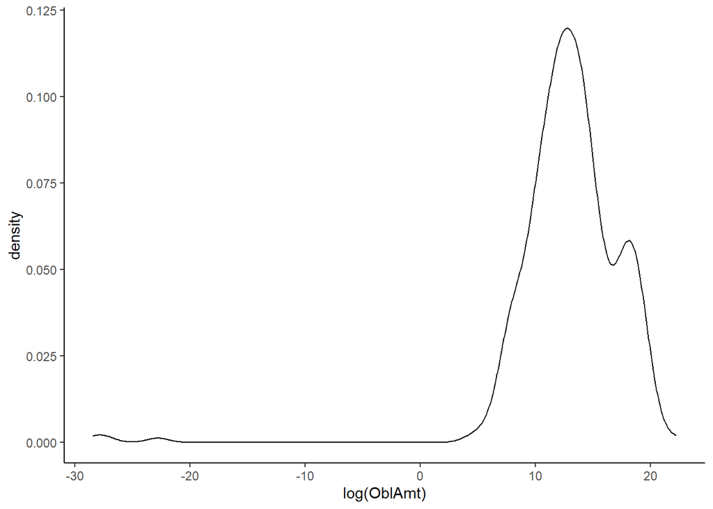

```r
#try a log transformation out of curiosity
ggplot2::ggplot(data = EDAdata, aes(x = log(OblAmt))) +
  geom_density()
```

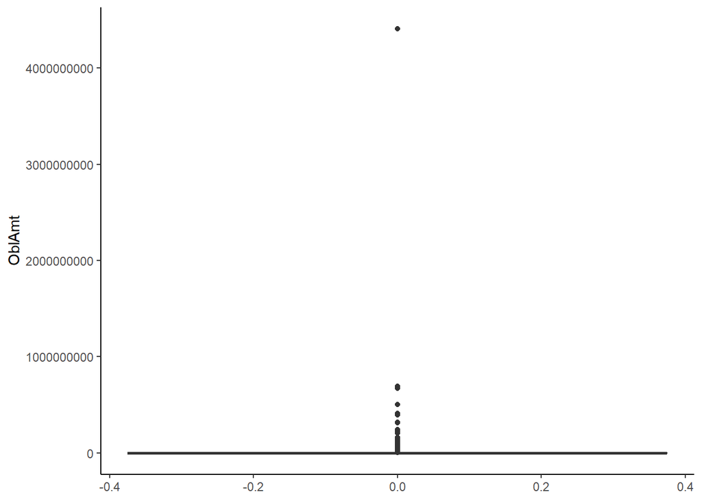

```r
#normal boxplot
ggplot2::ggplot(data = EDAdata, aes(y = OblAmt)) +
  geom_boxplot()
```

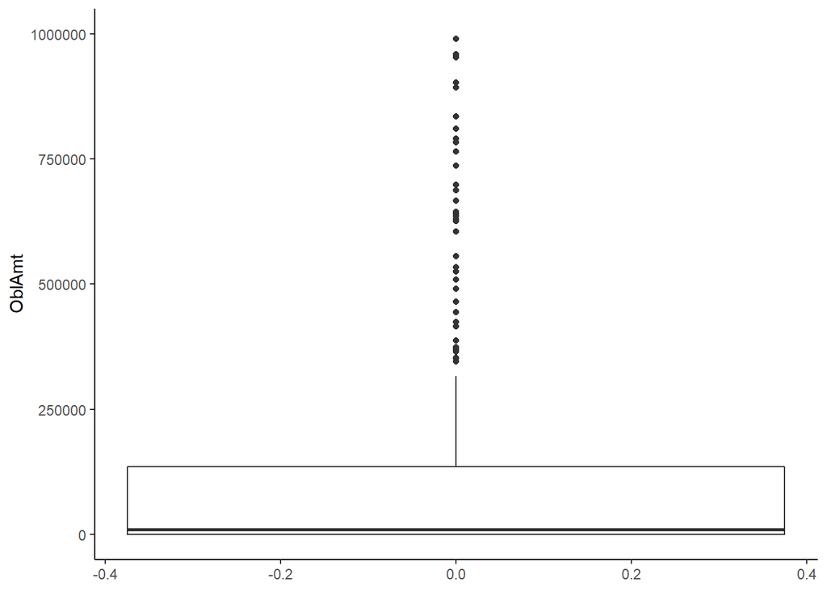

```r
#crop to $1M to get a better idea
ggplot2::ggplot(data = EDAdata, aes(y = OblAmt)) +
  geom_boxplot() +
  ylim(0, 1000000)
```

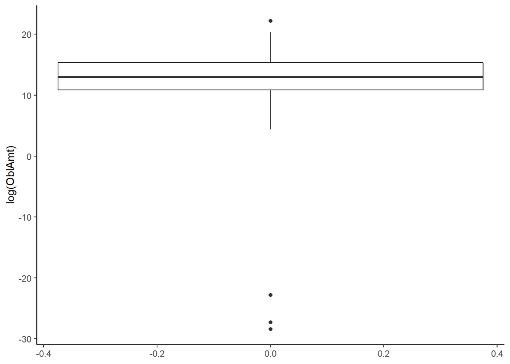

```r
#log transformed boxplot
ggplot2::ggplot(data = EDAdata, aes(y = log(OblAmt))) +
  geom_boxplot()
```

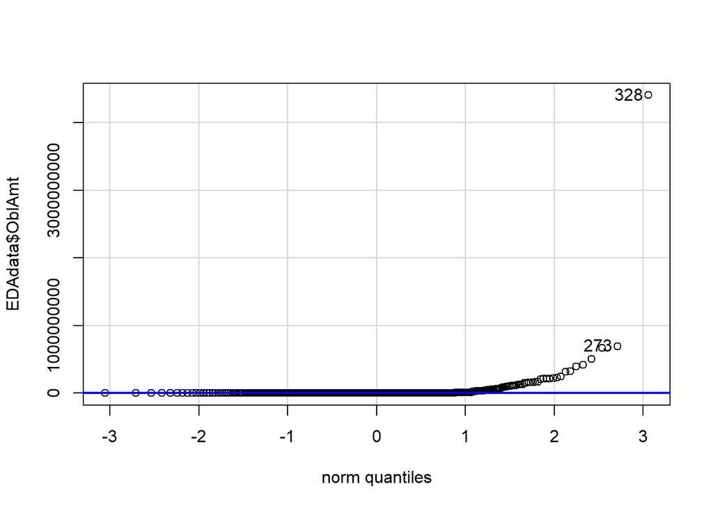

```
## [1] 328 273
```

```r
##QQ plot
car::qqPlot(EDAdata$OblAmt)
```

It appears that obligated funds and requested funds have similar distributions and characteristics. The same commentary about the requested funds analysis applies here as well.

## Predictor: State

```r
#frequency table since it's categorical
#hide NAs because there are no NAs
summarytools::freq(EDAdata$state, report.nas = FALSE)
```

```
## Frequencies
## EDAdata$state
## Type: Character
##
##               Freq        %   % Cum.
## ----------- ------ -------- --------
##          AK      8     1.79     1.79
##          AL     10     2.24     4.04
##          AR     10     2.24     6.28
##          AZ      3     0.67     6.95
##          CA     20     4.48    11.43
##          CO      6     1.35    12.78
##          CT      9     2.02    14.80
##          DC      3     0.67    15.47
##          DE      3     0.67    16.14
##          FL     18     4.04    20.18
##          GA     13     2.91    23.09
##          HI      7     1.57    24.66
##          IA     10     2.24    26.91
##          ID      6     1.35    28.25
##          IL      5     1.12    29.37
##          IN      3     0.67    30.04
##          KS      7     1.57    31.61
##          KY      7     1.57    33.18
##          LA     22     4.93    38.12
##          MA      6     1.35    39.46
##          ME      3     0.67    40.13
##          MI      7     1.57    41.70
##          MN     10     2.24    43.95
##          MO      8     1.79    45.74
##          MS     15     3.36    49.10
##          MT      2     0.45    49.55
##          NC     14     3.14    52.69
##          ND      6     1.35    54.04
##          NE      9     2.02    56.05
##          NH      7     1.57    57.62
##          NJ      5     1.12    58.74
##          NM      6     1.35    60.09
##          NV      3     0.67    60.76
##          NY     11     2.47    63.23
##          OH      7     1.57    64.80
##          OK     12     2.69    67.49
##          OR     10     2.24    69.73
##          PA      8     1.79    71.52
##          PR     11     2.47    73.99
##          RI      6     1.35    75.34
##          SC     13     2.91    78.25
##          SD     11     2.47    80.72
##          TN     11     2.47    83.18
##          TX     21     4.71    87.89
##          UT      1     0.22    88.12
##          VA      7     1.57    89.69
##          VT      6     1.35    91.03
##          WA     12     2.69    93.72
##          WI      9     2.02    95.74
##          WV     16     3.59    99.33
##          WY      3     0.67   100.00
##       Total    446   100.00   100.00
```

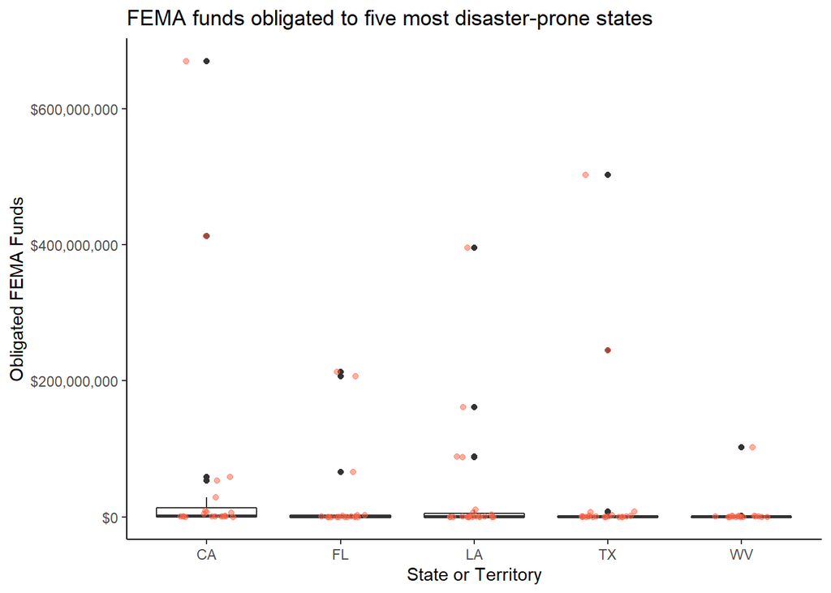

```r
#examine graphical relationship with outcomes
#include a jitter function to have a better idea of number of measurements and distribution
#filter top 5 states
#start with obligated amount
obl_fig_state <- EDAdata %>%
                    dplyr::add_count(state) %>%
                    dplyr::filter(dplyr::dense_rank(-n) < 6) %>%
                    ggplot2::ggplot(aes(x = state, y = OblAmt)) +
                      geom_boxplot() +
                      geom_jitter(alpha = 0.5, width = 0.2, height = 0.2, color = "tomato") +
                      scale_y_continuous(labels = scales::dollar_format()) +
                      labs(x = "State or Territory",
                           y = "Obligated FEMA Funds",
                           title = "FEMA funds obligated to five most disaster-prone states")
obl_fig_state
```

[figure not shown]

```r
#save file
obl_state_fig_file = here("results","obl-state.png")
ggsave(filename = obl_state_fig_file, plot = obl_fig_state)
#repeat for requested funds
req_fig_state <- EDAdata %>%
                    dplyr::add_count(state) %>%
                    dplyr::filter(dplyr::dense_rank(-n) < 6) %>%
                    ggplot2::ggplot(aes(x = state, y = ReqAmt)) +
                      geom_boxplot() +
                      geom_jitter(alpha = 0.5, width = 0.2, height = 0.2, color = "turquoise4") +
                      scale_y_continuous(labels = scales::dollar_format()) +
                      labs(x = "State or Territory",
                           y = "Requested FEMA Funds",
                           title = "FEMA funds requested by five most disaster-prone states")
req_fig_state
```

```r
#save file
req_state_fig_file = here("results","req-state.png")
ggsave(filename = req_state_fig_file, plot = req_fig_state)
#create a table where columns represent requested and obligated funds and rows are 5 most disaster-prone states
decs_state_5 <- EDAdata %>%
                    dplyr::add_count(state) %>%
                    dplyr::filter(dense_rank(-n) < 6) %>%
                    gtsummary::select(state, ReqAmt, OblAmt) %>%
                    gtsummary::tbl_summary(
                      by = state,
                      label = list(state ~ "State or Territory",
                                   ReqAmt ~ "Requested Funds",
                                   OblAmt ~ "Obligated Funds"),
                      statistic = list(all_continuous() ~ "{mean} ({sd})")) %>%
                    gtsummary::modify_header(label ~ "**Variable**") %>%
                    gtsummary::modify_spanning_header(c("stat_1", "stat_2", "stat_3", "stat_4", "stat_5") ~ "**State**") %>%
                    gtsummary::modify_caption("**Table 1. FEMA Funding for 5 Most Disaster-Prone States 2012 - 2021**") %>%
                    gtsummary::bold_labels()
decs_state_5
```

**Table 1. FEMA Funding for 5 Most Disaster-Prone States 2012 - 2021**

| **Variable** | **State** **CA**, N = 20<sup>1</sup> | **State** **FL**, N = 18<sup>1</sup> | **State** **LA**, N = 22<sup>1</sup> | **State** **TX**, N = 21<sup>1</sup> | **State** **WV**, N = 16<sup>1</sup> |
| --- | --- | --- | --- | --- | --- |
| Requested Funds | 62,605,465 (169,900,730) | 27,337,218 (68,075,813) | 34,318,344 (90,594,708) | 36,586,287 (119,143,196) | 6,659,588 (25,471,101) |
| Obligated Funds | 62,605,465 (169,900,730) | 27,337,218 (68,075,813) | 34,318,344 (90,594,708) | 36,637,886 (119,167,108) | 6,660,260 (25,470,955) |

<sup>*1*</sup> Mean (SD)

```r
#save file
decs_state_file = here("results", "decs-state-5.Rds")
saveRDS(decs_state_5, file = decs_state_file)
```

## Predictor: Incident Year

```r
#summary statistics since it's continuous
base::summary(EDAdata$IncidentYear)
```

```
##    Min. 1st Qu.  Median    Mean 3rd Qu.    Max.
##    2012    2015    2018    2017    2020    2021
```

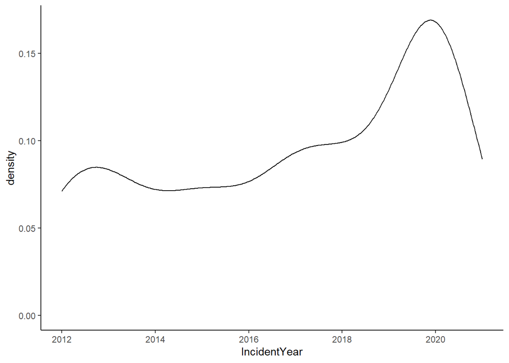

```r
#examine graphical relationship with outcomes

#density plot
ggplot2::ggplot(data = EDAdata, aes(x = IncidentYear)) +
  geom_density()
```

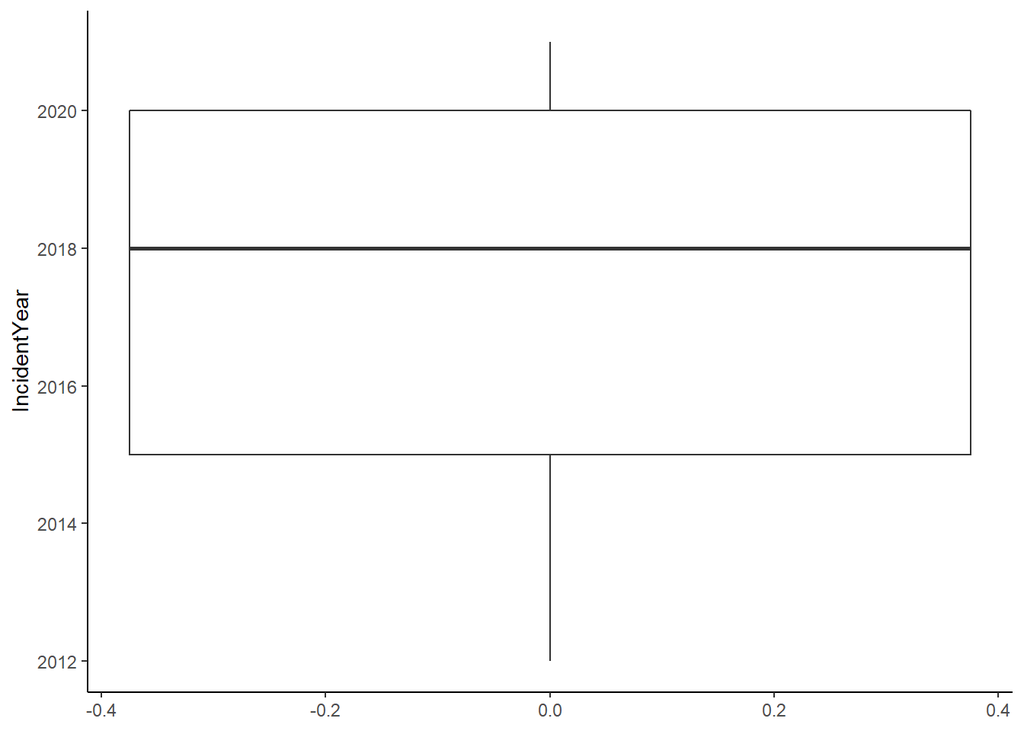

```r
#normal boxplot
ggplot2::ggplot(data = EDAdata, aes(y = IncidentYear)) +
  geom_boxplot()
```

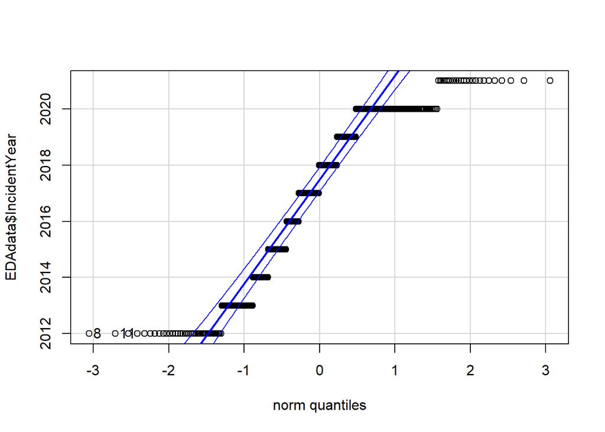

```
## [1]  8 11
```

```r
##QQ plot
car::qqPlot(EDAdata$IncidentYear)
```

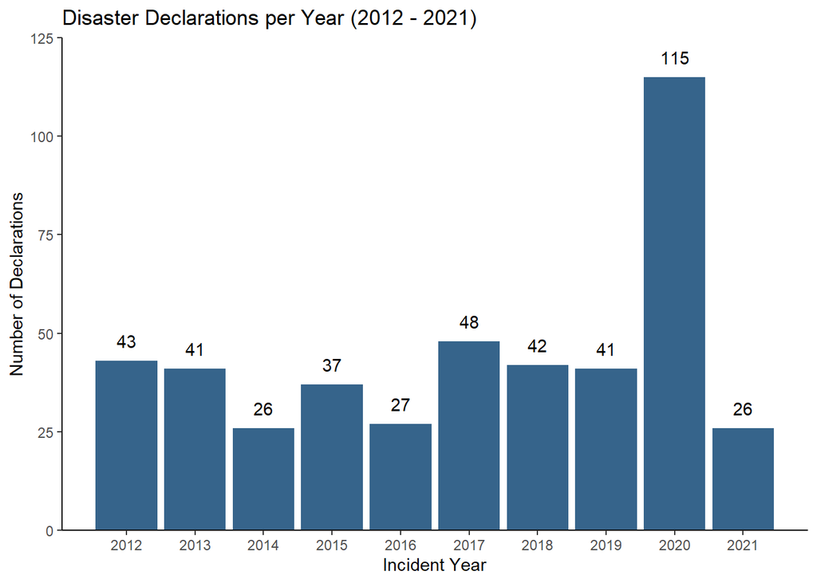

```r
#histogram distribution
year_hist <- EDAdata %>%
               ggplot2::ggplot(aes(x=IncidentYear)) +
                        geom_bar(fill="steelblue4") +
                        scale_x_continuous(breaks = seq(2012, 2021, by = 1)) +
                        scale_y_continuous(expand = c(0, 0), limits = c(0, 125)) +
                        geom_text(stat='count', aes(label=..count..), vjust=-1) +
                        labs(x = "Incident Year",
                             y = "Number of Declarations",
                             title = "Disaster Declarations per Year (2012 - 2021)")
year_hist
```

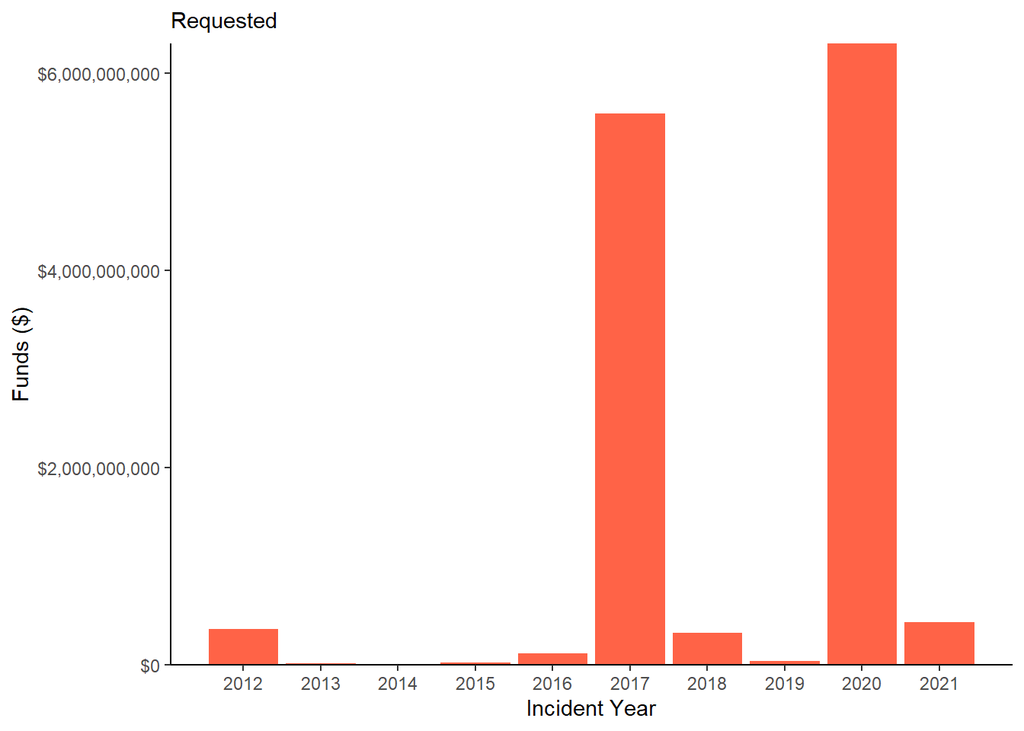

```r
#save file
year_fig_file = here("results","incidentyear.png")
ggsave(filename = year_fig_file, plot = year_hist)
#examine graphical relationship with outcomes of interest
#look at total cost per incident year
req_fig_year <- EDAdata %>%
                    ggplot2::ggplot(aes(x = IncidentYear)) +
                      geom_bar(aes(y = ReqAmt),
                               stat = "identity",
                               fill = "tomato") +
                      scale_y_continuous(expand = c(0, 0),
                                         labels = scales::dollar_format()) +
                      scale_x_continuous(breaks = seq(2012, 2021, by = 1)) +
                      labs(x = "Incident Year",
                           y = "Funds ($)",
                           subtitle = "Requested")
req_fig_year
```

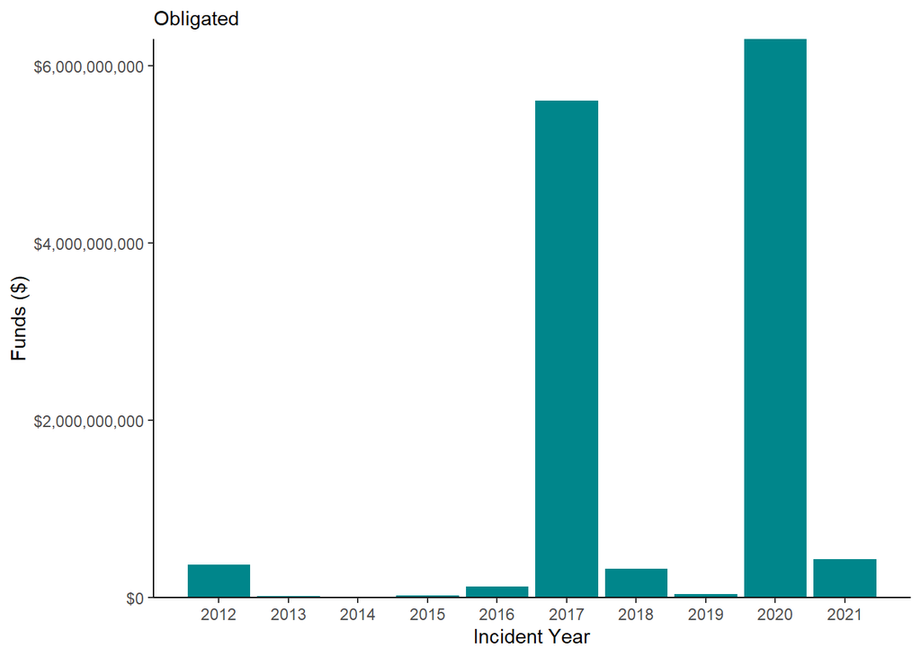

```r
#repeat for obligated funds
obl_fig_year <- EDAdata %>%
                    ggplot2::ggplot(aes(x = IncidentYear)) +
                      geom_bar(aes(y = OblAmt),
                               stat = "identity",
                               fill = "turquoise4") +
                      scale_y_continuous(expand = c(0, 0),
                                         labels = scales::dollar_format()) +
                      scale_x_continuous(breaks = seq(2012, 2021, by = 1)) +
                      labs(x = "Incident Year",
                           y = "Funds ($)",
                           subtitle = "Obligated")
obl_fig_year
```